# HW8

Vinh Le

June 29, 2016

# Introduction

This tutorial is based on the EDA Exercises in the book, Doing Data Science, which I highly recommend.

There are 31 data sets named nyt1.csv, nyt2.csv,…, nyt31.csv, which can be downloaded from GitHub.

Each csv represents one (simulated) days worth of ads shown and clicks recorded on the New York Times homepage in May 2012. Each row in the csv represents a single user.

There are five columns: Age, Gender (0=female, 1=male), Impressions, Clicks, and Signed_In status (0=not signed in, 1=signed in).

# Getting the Data

Create a data frame called data1 from the nyt1.csv file

```r
fileLocation <- "http://stat.columbia.edu/~rachel/datasets/nyt1.csv"
data1 <- read.csv(url(fileLocation))

# Use the section below if you would rather import the data from a local file
# fileLocation <- "~/path/for/the/file/nyt1.csv"
# data1 <- read.csv("fileLocation")
```

```r
head(data1)
```

```
##   Age Gender Impressions Clicks Signed_In
## 1  36      0           3      0         1
## 2  73      1           3      0         1
## 3  30      0           3      0         1
## 4  49      1           3      0         1
## 5  47      1          11      0         1
## 6  47      0          11      1         1
```

You can get a overview of the structure of the data by using the str() function

```r
str(data1) # str stands for 'structure'
```

```
## 'data.frame':    458441 obs. of  5 variables:
##  $ Age        : int  36 73 30 49 47 47 0 46 16 52 ...
##  $ Gender     : int  0 1 0 1 1 0 0 0 0 0 ...
##  $ Impressions: int  3 3 3 3 11 11 7 5 3 4 ...
##  $ Clicks     : int  0 0 0 0 0 1 1 0 0 0 ...
##  $ Signed_In  : int  1 1 1 1 1 1 0 1 1 1 ...
```

```r
# str() returns information about each column such as name, data type, etc.
```

```r
summary(data1)
```

```
##       Age             Gender       Impressions         Clicks
##  Min.   :  0.00   Min.   :0.000   Min.   : 0.000   Min.   :0.00000
##  1st Qu.:  0.00   1st Qu.:0.000   1st Qu.: 3.000   1st Qu.:0.00000
##  Median : 31.00   Median :0.000   Median : 5.000   Median :0.00000
##  Mean   : 29.48   Mean   :0.367   Mean   : 5.007   Mean   :0.09259
##  3rd Qu.: 48.00   3rd Qu.:1.000   3rd Qu.: 6.000   3rd Qu.:0.00000
##  Max.   :108.00   Max.   :1.000   Max.   :20.000   Max.   :4.00000
##    Signed_In
##  Min.   :0.0000
##  1st Qu.:0.0000
##  Median :1.0000
##  Mean   :0.7009
##  3rd Qu.:1.0000
##  Max.   :1.0000
```

Since we’re exploring, it’s helpful to visualize the distribution of some of the columns, so we can see what we’re working with and if anything looks out of the ordinary

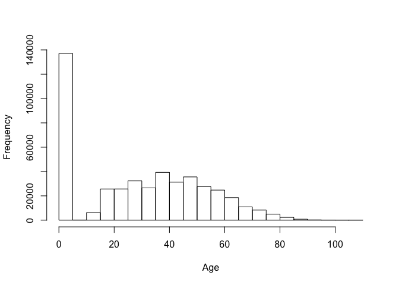

```r
# distribution of the Age column
hist(data1$Age, main="", xlab="Age")
```

```r
range(data1$Age)
```

```
## [1]   0 108
```

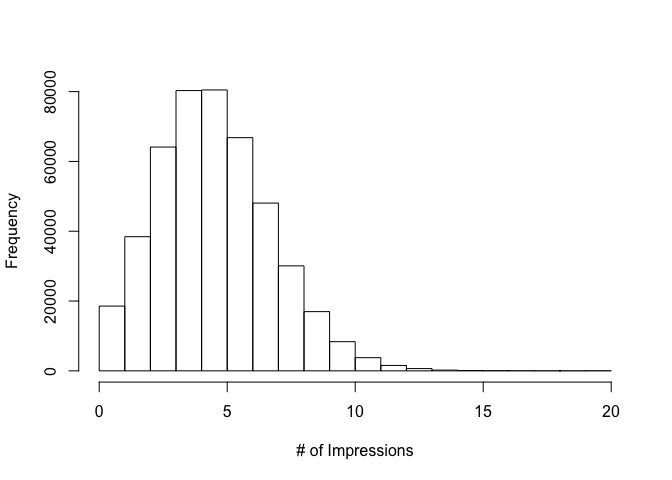

```r
# distribution of the Impressions column
hist(data1$Impressions, main="", xlab="# of Impressions")
```

```r
range(data1$Impressions)
```

```
## [1]  0 20
```

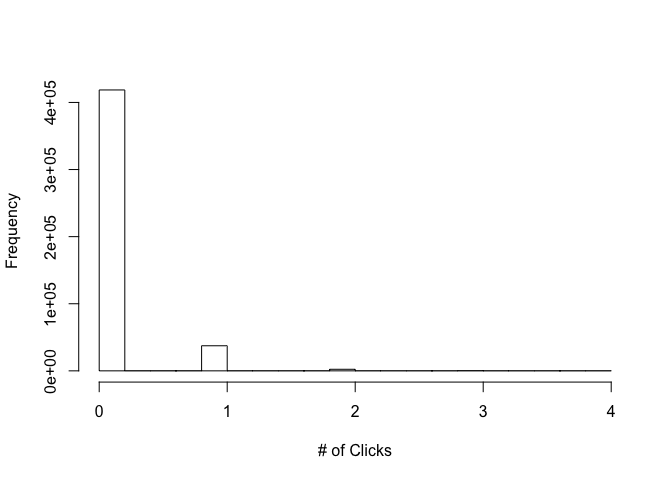

```r
# distribution of the Clicks column
hist(data1$Clicks, main="", xlab="# of Clicks")
```

```r
range(data1$Clicks)
```

```
## [1] 0 4
```

Did you notice that there is a disproportionate number of ages recorded as zero? This could skew our analysis, so we may need to account for that later.

# Task 1

create a new variable named Age_Group, that groups users into age categories “<18”, “18-24”, “25-34”, “35-44”, “45-54”, “55-64”, and “65+”

1.1) Cut the ages into the desired groups and add the groups to a new column in data1 called Age_Group. The ‘cut’ function creates a factor with levels

```r
data1$Age_Group <- cut(data1$Age, c(-Inf, 18, 24, 34, 44, 54, 64, Inf))

levels(data1$Age_Group) <- c("<18", "18-24", "25-34", "35-44", "45-54", "55-64", "65+")
# Name the levels of 'Age_Group' for readability
```

Take a look at the changes:

```r
head(data1)
```

```
##   Age Gender Impressions Clicks Signed_In Age_Group
## 1  36      0           3      0         1     35-44
## 2  73      1           3      0         1       65+
## 3  30      0           3      0         1     25-34
## 4  49      1           3      0         1     45-54
## 5  47      1          11      0         1     45-54
## 6  47      0          11      1         1     45-54
```

# Task 2

For a single day, plot the distributions of ‘number of impressions’ and ‘click-through-rate’ by Age_Group. (CTR = clicks/impressions).

2.1) Create a subset of data1 to exclude rows where there are no impressions (if there are no impressions, we assume there will be no clicks). Name the new object ImpSub

```r
ImpSub <- subset(data1, Impressions>0)
```

2.2) Add a column to ImpSub called CTR containing the click-through-rate

```r
ImpSub$CTR <- ImpSub$Clicks/ImpSub$Impressions

head(ImpSub)
```

```
##   Age Gender Impressions Clicks Signed_In Age_Group        CTR
## 1  36      0           3      0         1     35-44 0.00000000
## 2  73      1           3      0         1       65+ 0.00000000
## 3  30      0           3      0         1     25-34 0.00000000
## 4  49      1           3      0         1     45-54 0.00000000
## 5  47      1          11      0         1     45-54 0.00000000
## 6  47      0          11      1         1     45-54 0.09090909
```

2.3) Plot the distribution of Impressions>0, grouped by Age_Group, using the ggplot2 package

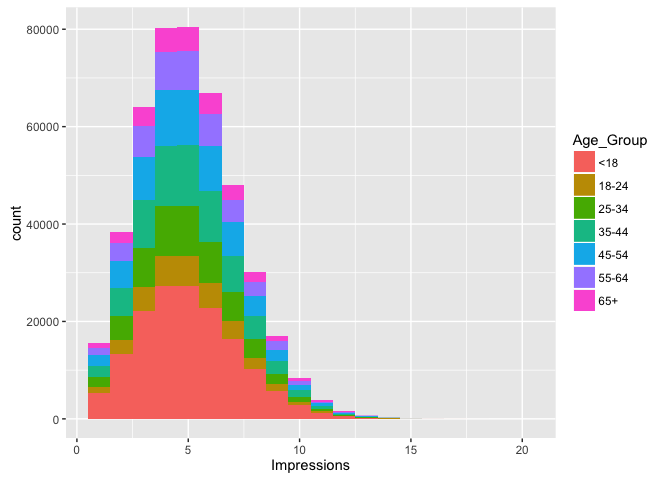

```r
library(ggplot2) # used for visualizations
ggplot(subset(ImpSub, Impressions>0), aes(x=Impressions, fill=Age_Group))+
    geom_histogram(binwidth=1)
```

2.4) Plot the distribution of CTR>0, grouped by Age_Group

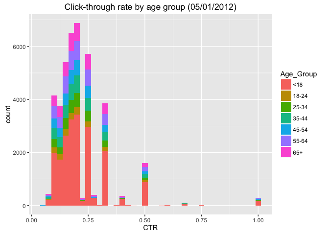

```r
ggplot(subset(ImpSub, CTR>0), aes(x=CTR, fill=Age_Group))+
    labs(title="Click-through rate by age group (05/01/2012)")+
    geom_histogram(binwidth=.025)
```

# Plot the distribution of CTR and Age Group

[figure not shown]

```r
ggplot(subset(ImpSub, CTR>0), aes(x=CTR, fill=Age_Group))+
    labs(title="Click-through rate by age group (05/14/2012)")+
    geom_histogram(binwidth=.025)
```

# Define a new variable to segment user based on click-through-rate (CTR) behavior

```r
ImpSub$CTR_Group <- cut(ImpSub$CTR, c(-Inf, 0.2, 0.4, 0.6, 0.8, Inf))

levels(ImpSub$CTR_Group) <- c("<0.2", "0.2-0.4", "0.4-0.6", "0.6-0.8", "0.8+")
# Name the levels of 'CTR_Group' for readability
```

# TIDY DATA

Remove Age with values of zero

```r
ImpSub<-subset(ImpSub,ImpSub$Age>0)
```

# Get the total number of Male, Impressions, Clicks and Signed-in (0=Female, 1=Male)

Number of Male users

```r
sum(ImpSub$Gender == 1)
```

```
## [1] 167146
```

Number of Impressions

```r
sum(ImpSub$Impression)
```

```
## [1] 1610076
```

Number of Clicks

```r
sum(ImpSub$Clicks)
```

```
## [1] 22969
```

Number of Signed-in

```r
sum(ImpSub$Signed_In)
```

```
## [1] 319198
```

# Get the mean of Age, Impression, Clicks, CTR and percentage of males and signed-in

Average Age

```r
mean(ImpSub$Age)
```

```
## [1] 42.06255
```

Average Impression

```r
mean(ImpSub$Impressions)
```

```
## [1] 5.044129
```

Average Clicks

```r
mean(ImpSub$Clicks)
```

```
## [1] 0.07195847
```

Average CTR

```r
mean(ImpSub$CTR)
```

```
## [1] 0.01425364
```

Average % of Males

```r
100 * sum(ImpSub$Gender==1)/length(ImpSub$Gender)
```

```
## [1] 52.36436
```

Average % of Signed_in

```r
100 * sum(ImpSub$Signed_In)/length(ImpSub$Gender)
```

```
## [1] 100
```

# Get the means of Impression, Clicks, CTR and percentage of males and signed_in by AgeGroup

Mean of Impressions by AgeGroup

```r
aggregate(ImpSub$Impressions,list(ImpSub$Age_Group),mean)
```

```
##   Group.1        x
## 1     <18 5.031894
## 2   18-24 5.043240
## 3   25-34 5.026055
## 4   35-44 5.054749
## 5   45-54 5.045172
## 6   55-64 5.053484
## 7     65+ 5.046925
```

Mean of Clicks by AgeGroup

```r
aggregate(ImpSub$Clicks,list(ImpSub$Age_Group),mean)
```

```
##   Group.1          x
## 1     <18 0.13191467
## 2   18-24 0.04880905
## 3   25-34 0.05081227
## 4   35-44 0.05202148
## 5   45-54 0.05062260
## 6   55-64 0.10246952
## 7     65+ 0.15233226
```

Mean of CTR by AgeGroup

```r
aggregate(ImpSub$CTR,list(ImpSub$Age_Group),mean)
```

```
##   Group.1           x
## 1     <18 0.026620504
## 2   18-24 0.009720481
## 3   25-34 0.010146329
## 4   35-44 0.010286330
## 5   45-54 0.009957612
## 6   55-64 0.020306816
## 7     65+ 0.029802702
```

Percentage of Males by AgeGroup

```r
mAgetotal <- aggregate(ImpSub$Gender == 1,list(ImpSub$Age_Group), sum)
 mAgelength<- aggregate(ImpSub$Age_Group, list(ImpSub$Age_Group), length)
merged <- merge(mAgetotal,mAgelength,by="Group.1")
names(merged) <- c("AgeGroup","MalesTotal","Total")
merged$pct <- round(100 * merged$MalesTotal/merged$Total,2)
merged
```

```
##   AgeGroup MalesTotal Total   pct
## 1      <18      12279 19126 64.20
## 2    18-24      18697 35014 53.40
## 3    25-34      30750 57801 53.20
## 4    35-44      37429 70394 53.17
## 5    45-54      33788 63845 52.92
## 6    55-64      23830 44462 53.60
## 7      65+      10373 28556 36.33
```

Percentage of Signed_in by AgeGroup

```r
meanSigned <- aggregate(ImpSub$Signed_In == 1,list(ImpSub$Age_Group), sum)
mAgelength <- aggregate(ImpSub$Age_Group, list(ImpSub$Age_Group), length)
merged <- merge(meanSigned,mAgelength,by="Group.1")
names(merged) <- c("AgeGroup","SignedTotal","Total")
merged$pct <- round(100 * merged$SignedTotal/merged$Total,2)
merged
```

```
##   AgeGroup SignedTotal Total pct
## 1      <18       19126 19126 100
## 2    18-24       35014 35014 100
## 3    25-34       57801 57801 100
## 4    35-44       70394 70394 100
## 5    45-54       63845 63845 100
## 6    55-64       44462 44462 100
## 7      65+       28556 28556 100
```

# Create a table of CTRGroup vs AgeGroup counts

```r
table(ImpSub$CTR_Group, ImpSub$Age_Group)
```

```
##
##             <18 18-24 25-34 35-44 45-54 55-64   65+
##   <0.2    18339 34540 56980 69424 62936 43147 27261
##   0.2-0.4   640   391   689   820   776  1104  1108
##   0.4-0.6   121    68   106   118   113   168   156
##   0.6-0.8     6     2     7     4     0     7    10
##   0.8+       20    13    19    28    20    36    21
```

# Plot distribution of number impressions and click-through-rate (CTR=click/impression) for the age groups

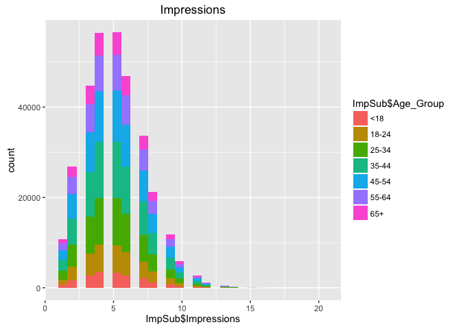

```r
#Plot of Impression
qplot(ImpSub$Impressions, main ="Impressions", fill=ImpSub$Age_Group)
```

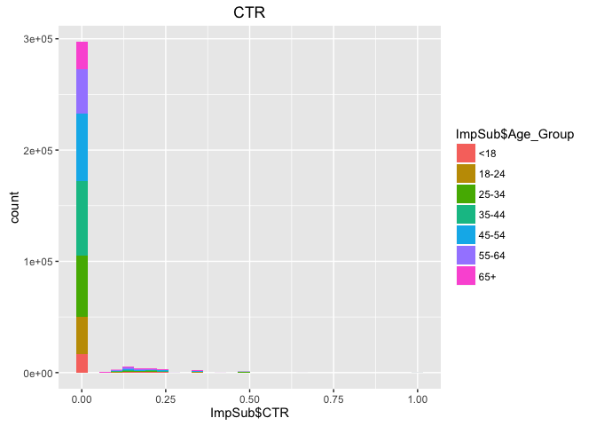

```r
#Plot of CTR
qplot(ImpSub$CTR, main="CTR", fill=ImpSub$Age_Group)
```

# One more plot you think which is important to look at.

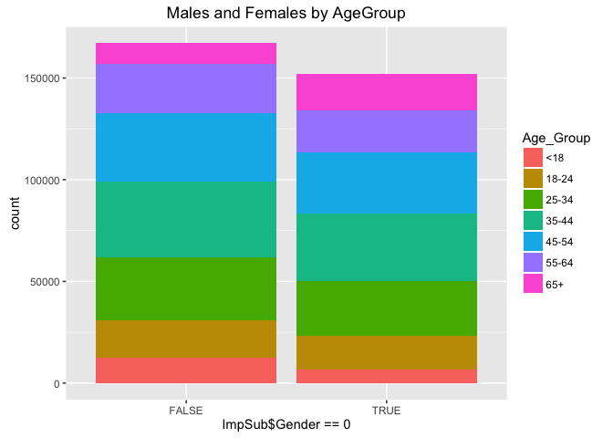

```r
qplot(ImpSub$Gender==0, data=ImpSub, fill=Age_Group,
      main="Males and Females by AgeGroup")
```